# Taller 7

### Paquete *MTS*

MTS es un paquete general que permite analizar series de tiempo multivariadas lineales, pero que requiere un alto costo computacional, poco intuitivo y, por lo tanto, poco objetivo; por lo que no es un paquete muy recomendado para iniciarse en series multivariadas.

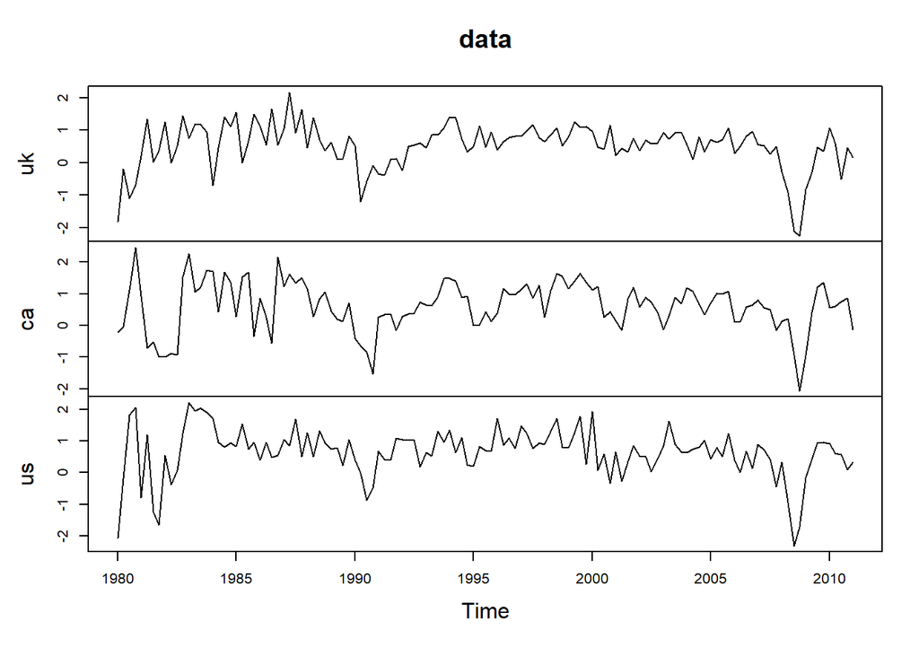

```r
unloadNamespace("vars") # eliminar el paquete de la memoria
library(MTS)

MTSplot(gdp.ret)
```

```r
VARorder(gdp.ret)
```

```
## selected order: aic =  2
## selected order: bic =  1
## selected order: hq =  1
## Summary table:
##        p     AIC     BIC      HQ     M(p) p-value
##  [1,]  0 -3.3250 -3.3250 -3.3250   0.0000  0.0000
##  [2,]  1 -4.2520 -4.0484 -4.1693 115.1329  0.0000
##  [3,]  2 -4.3333 -3.9260 -4.1678  23.5389  0.0051
##  [4,]  3 -4.2926 -3.6817 -4.0444  10.4864  0.3126
##  [5,]  4 -4.2661 -3.4516 -3.9352  11.5767  0.2382
##  [6,]  5 -4.1508 -3.1326 -3.7372   2.7406  0.9737
##  [7,]  6 -4.0801 -2.8583 -3.5838   6.7822  0.6598
##  [8,]  7 -3.9869 -2.5615 -3.4079   4.5469  0.8719
##  [9,]  8 -4.1260 -2.4969 -3.4642  24.4833  0.0036
## [10,]  9 -4.0586 -2.2259 -3.3141   6.4007  0.6992
## [11,] 10 -3.9683 -1.9320 -3.1411   4.3226  0.8889
## [12,] 11 -3.9726 -1.7326 -3.0626  11.4922  0.2435
## [13,] 12 -3.9872 -1.5436 -2.9945  11.8168  0.2238
## [14,] 13 -4.0408 -1.3935 -2.9654  14.1266  0.1179
```

```r
criterios <- data.frame(cbind(round(0:13,0),VARorder(gdp.ret)$aic,
                              VARorder(gdp.ret)$bic,
                              VARorder(gdp.ret)$hq))
```

```
## selected order: aic =  2
## selected order: bic =  1
## selected order: hq =  1
## Summary table:
##        p     AIC     BIC      HQ     M(p) p-value
##  [1,]  0 -3.3250 -3.3250 -3.3250   0.0000  0.0000
##  [2,]  1 -4.2520 -4.0484 -4.1693 115.1329  0.0000
##  [3,]  2 -4.3333 -3.9260 -4.1678  23.5389  0.0051
##  [4,]  3 -4.2926 -3.6817 -4.0444  10.4864  0.3126
##  [5,]  4 -4.2661 -3.4516 -3.9352  11.5767  0.2382
##  [6,]  5 -4.1508 -3.1326 -3.7372   2.7406  0.9737
##  [7,]  6 -4.0801 -2.8583 -3.5838   6.7822  0.6598
##  [8,]  7 -3.9869 -2.5615 -3.4079   4.5469  0.8719
##  [9,]  8 -4.1260 -2.4969 -3.4642  24.4833  0.0036
## [10,]  9 -4.0586 -2.2259 -3.3141   6.4007  0.6992
```

[output cut: 42 more lines]

```r
names(criterios) <- c('p', 'AIC', 'BIC', 'HQ')

plot.crite <- data.frame(rbind(cbind(round(0:13,0), 'AIC', VARorder(gdp.ret)$aic),
                               cbind(round(0:13,0), 'BIC', VARorder(gdp.ret)$bic),
                               cbind(round(0:13,0), 'HQ', VARorder(gdp.ret)$hq)))
```

```
## selected order: aic =  2
## selected order: bic =  1
## selected order: hq =  1
## Summary table:
##        p     AIC     BIC      HQ     M(p) p-value
##  [1,]  0 -3.3250 -3.3250 -3.3250   0.0000  0.0000
##  [2,]  1 -4.2520 -4.0484 -4.1693 115.1329  0.0000
##  [3,]  2 -4.3333 -3.9260 -4.1678  23.5389  0.0051
##  [4,]  3 -4.2926 -3.6817 -4.0444  10.4864  0.3126
##  [5,]  4 -4.2661 -3.4516 -3.9352  11.5767  0.2382
##  [6,]  5 -4.1508 -3.1326 -3.7372   2.7406  0.9737
##  [7,]  6 -4.0801 -2.8583 -3.5838   6.7822  0.6598
##  [8,]  7 -3.9869 -2.5615 -3.4079   4.5469  0.8719
##  [9,]  8 -4.1260 -2.4969 -3.4642  24.4833  0.0036
## [10,]  9 -4.0586 -2.2259 -3.3141   6.4007  0.6992
```

[output cut: 42 more lines]

```r
names(plot.crite) <- c('p', 'Criterio', 'Valores')
plot.crite$p       <- as.numeric(as.character(plot.crite$p))
plot.crite$Valores <- as.numeric(as.character(plot.crite$Valores))
```

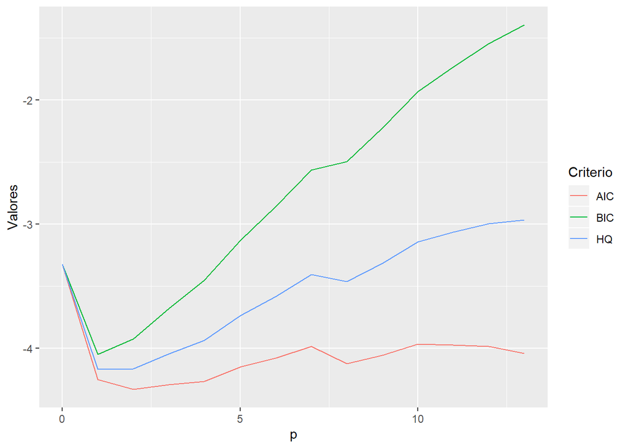

```r
ggplot(plot.crite, aes(x = p,y = Valores, group = Criterio)) +
  geom_line(aes(color = Criterio))
```

```r
modelo <- VAR(gdp.ret, 2)
```

```
## Constant term:
## Estimates:  0.1258163 0.1231581 0.2895581
## Std.Error:  0.07266338 0.07382941 0.0816888
## AR coefficient matrix
## AR( 1 )-matrix
##       [,1]  [,2]   [,3]
## [1,] 0.393 0.103 0.0521
## [2,] 0.351 0.338 0.4691
## [3,] 0.491 0.240 0.2356
## standard error
##        [,1]   [,2]   [,3]
## [1,] 0.0934 0.0984 0.0911
## [2,] 0.0949 0.1000 0.0926
## [3,] 0.1050 0.1106 0.1024
## AR( 2 )-matrix
##         [,1]   [,2]     [,3]
## [1,]  0.0566  0.106  0.01889
## [2,] -0.1914 -0.175 -0.00868
## [3,] -0.3120 -0.131  0.08531
## standard error
##        [,1]   [,2]   [,3]
## [1,] 0.0924 0.0876 0.0938
## [2,] 0.0939 0.0890 0.0953
## [3,] 0.1038 0.0984 0.1055
##
## Residuals cov-mtx:
##            [,1]       [,2]       [,3]
## [1,] 0.28244420 0.02654091 0.07435286
## [2,] 0.02654091 0.29158166 0.13948786
## [3,] 0.07435286 0.13948786 0.35696571
##
## det(SSE) =  0.02258974
## AIC =  -3.502259
## BIC =  -3.094982
## HQ  =  -3.336804
```

En cuanto al diagnostico, el paquete MTS no incluye test propios aplicados a objetos de tipo `var` o similares para determinar un analisis de los residuos, lo cual es una clara desventaja frete al paquete `vars`. Para determinar la posible correlacion de los residuos, se hace de manera grafica mediante la funcion `mq`, la cual genera estadisticos de Ljung-Box multivariados para matrices de correlacion cruzada.

```r
resi <- modelo$residuals
mq(resi,adj=18)
```

```
## Ljung-Box Statistics:
##           m       Q(m)     df    p-value
##  [1,]   1.000     0.816  -9.000     1.00
##  [2,]   2.000     3.978   0.000     1.00
##  [3,]   3.000    16.665   9.000     0.05
##  [4,]   4.000    35.122  18.000     0.01
##  [5,]   5.000    38.189  27.000     0.07
##  [6,]   6.000    41.239  36.000     0.25
##  [7,]   7.000    47.621  45.000     0.37
##  [8,]   8.000    61.677  54.000     0.22
##  [9,]   9.000    67.366  63.000     0.33
## [10,]  10.000    76.930  72.000     0.32
## [11,]  11.000    81.567  81.000     0.46
## [12,]  12.000    93.112  90.000     0.39
## [13,]  13.000   105.327  99.000     0.31
## [14,]  14.000   116.279 108.000     0.28
## [15,]  15.000   128.974 117.000     0.21
## [16,]  16.000   134.704 126.000     0.28
## [17,]  17.000   138.552 135.000     0.40
## [18,]  18.000   146.256 144.000     0.43
## [19,]  19.000   162.418 153.000     0.29
## [20,]  20.000   171.948 162.000     0.28
## [21,]  21.000   174.913 171.000     0.40
## [22,]  22.000   182.056 180.000     0.44
## [23,]  23.000   190.276 189.000     0.46
## [24,]  24.000   202.141 198.000     0.41
```

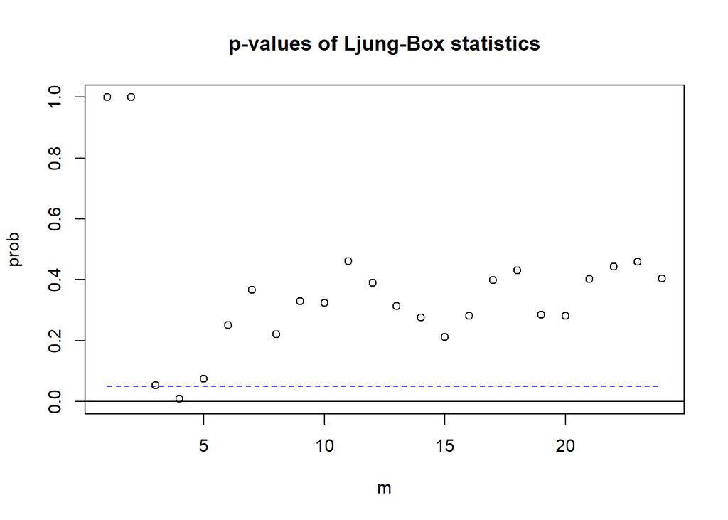

Una de las ventajas en cuanto al diagnostico del modelo con `MTS` es que permite refinar el modelo en caso de que este no cumpla con los supuestos, eliminando parametros no significativos. Posteriormente, la funcion `MTSdiag` genera un diagnostico con una alta carga computacional, un poco extenso y no tan visible.

```r
modelo.2 <- refVAR(modelo, thres = 1.96)
```

```
## Constant term:
## Estimates:  0.1628247 0 0.2827525
## Std.Error:  0.06814101 0 0.07972864
## AR coefficient matrix
## AR( 1 )-matrix
##       [,1]  [,2]  [,3]
## [1,] 0.467 0.207 0.000
## [2,] 0.334 0.270 0.496
## [3,] 0.468 0.225 0.232
## standard error
##        [,1]   [,2]   [,3]
## [1,] 0.0790 0.0686 0.0000
## [2,] 0.0921 0.0875 0.0913
## [3,] 0.1027 0.0963 0.1023
## AR( 2 )-matrix
##        [,1] [,2] [,3]
## [1,]  0.000    0    0
## [2,] -0.197    0    0
## [3,] -0.301    0    0
## standard error
##        [,1] [,2] [,3]
## [1,] 0.0000    0    0
## [2,] 0.0921    0    0
## [3,] 0.1008    0    0
##
## Residuals cov-mtx:
##            [,1]       [,2]       [,3]
## [1,] 0.29003669 0.01803456 0.07055856
## [2,] 0.01803456 0.30802503 0.14598345
## [3,] 0.07055856 0.14598345 0.36268779
##
## det(SSE) =  0.02494104
## AIC =  -3.531241
## BIC =  -3.304976
## HQ  =  -3.439321
```

```r
MTSdiag(modelo.2, adj=12)
```

```
## [1] "Covariance matrix:"
##        uk     ca     us
## uk 0.2924 0.0182 0.0711
## ca 0.0182 0.3084 0.1472
## us 0.0711 0.1472 0.3657
## CCM at lag:  0
##        [,1]   [,2]  [,3]
## [1,] 1.0000 0.0605 0.218
## [2,] 0.0605 1.0000 0.438
## [3,] 0.2175 0.4382 1.000
## Simplified matrix:
## CCM at lag:  1
## . . .
## . . .
## . . .
## CCM at lag:  2
## . . .
## . . .
## . . .
## CCM at lag:  3
## . . .
## . . .
## . . .
## CCM at lag:  4
## . . -
## . . .
## . . .
## CCM at lag:  5
## . . .
## . . .
## . . .
## CCM at lag:  6
## . . .
## . . .
## . . .
## CCM at lag:  7
## . . .
## . . .
## . . .
## CCM at lag:  8
```

[output cut: 52 more lines]

```
## . . .
## . . .
## . . .
## CCM at lag:  22
## . . .
## . . .
## . . .
## CCM at lag:  23
## . . .
## . . .
## . . .
## CCM at lag:  24
## . . .
## . . .
## . . .
```

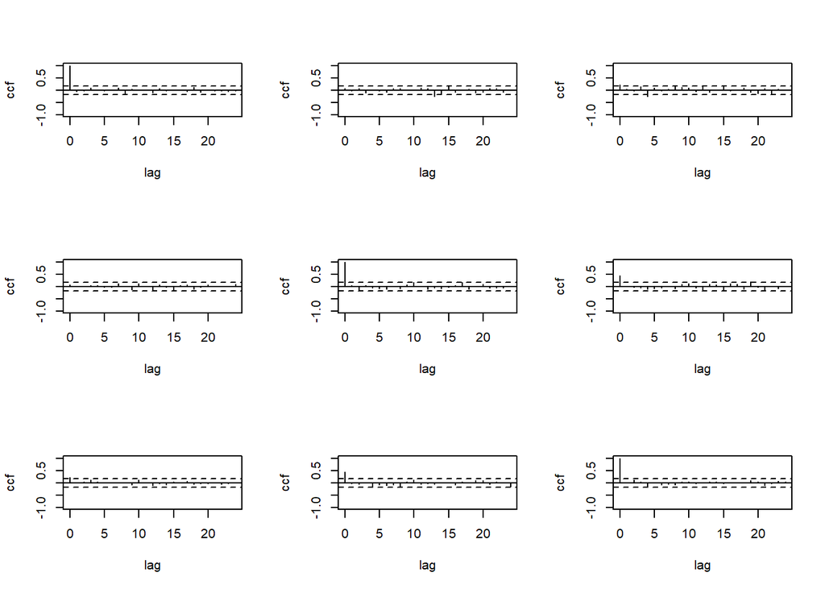

```
## Hit Enter for p-value plot of individual ccm:
```

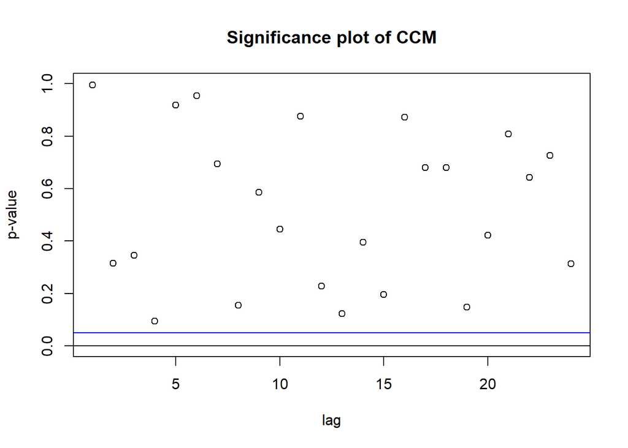

```
## Hit Enter to compute MQ-statistics:
##
## Ljung-Box Statistics:
##          m       Q(m)     df    p-value
##  [1,]   1.00      1.78   -3.00     1.00
##  [2,]   2.00     12.41    6.00     1.00
##  [3,]   3.00     22.60   15.00     0.09
##  [4,]   4.00     37.71   24.00     0.04
##  [5,]   5.00     41.65   33.00     0.14
##  [6,]   6.00     44.95   42.00     0.35
##  [7,]   7.00     51.50   51.00     0.45
##  [8,]   8.00     64.87   60.00     0.31
##  [9,]   9.00     72.50   69.00     0.36
## [10,]  10.00     81.58   78.00     0.37
## [11,]  11.00     86.12   87.00     0.51
## [12,]  12.00     98.08   96.00     0.42
## [13,]  13.00    112.31  105.00     0.30
## [14,]  14.00    121.89  114.00     0.29
## [15,]  15.00    134.58  123.00     0.22
## [16,]  16.00    139.16  132.00     0.32
## [17,]  17.00    145.85  141.00     0.37
## [18,]  18.00    152.56  150.00     0.43
## [19,]  19.00    165.91  159.00     0.34
## [20,]  20.00    175.22  168.00     0.34
## [21,]  21.00    180.56  177.00     0.41
## [22,]  22.00    187.40  186.00     0.46
## [23,]  23.00    193.78  195.00     0.51
## [24,]  24.00    204.65  204.00     0.47
```

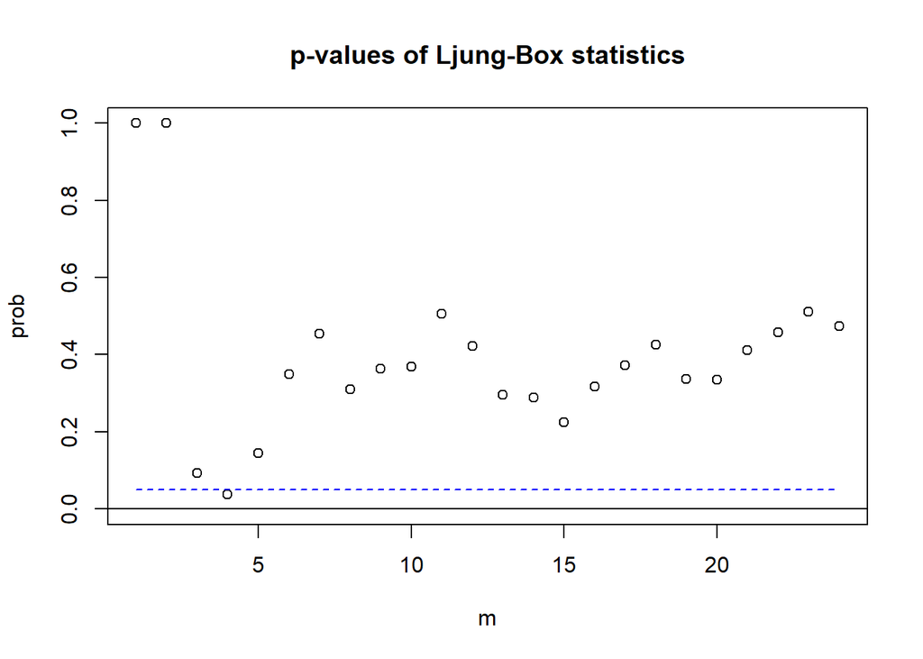

```
## Hit Enter to obtain residual plots:
```

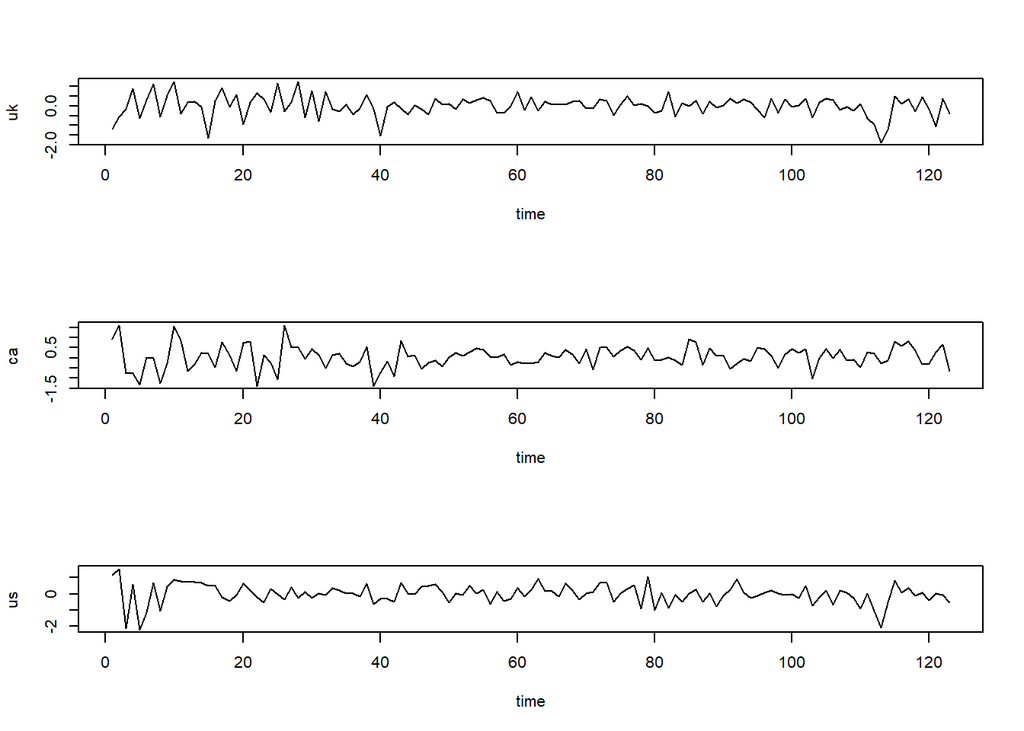

Otro aspecto importante del paquete MTS es su singularidad para generar funciones de impulso y descomposición de varianza residual, ya que requiere de un componente teorico mayor para entender los parametros de entrada que piden las funciones `VARirf` y `FEVdec`.

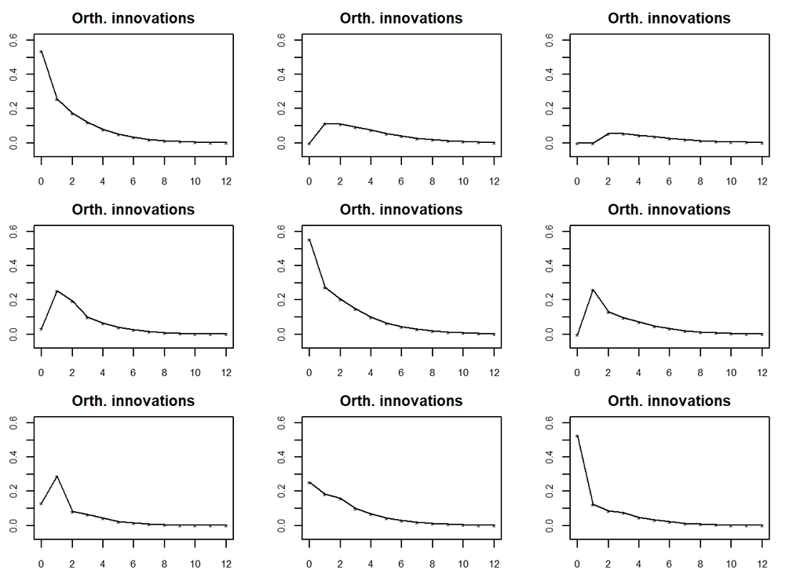

```
## Press return to continue
```

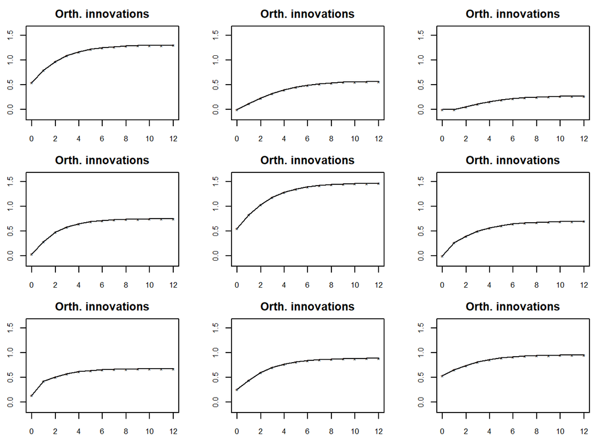

```r
# funciones de impulso
Phi <- modelo.2$Phi
Sig <- modelo.2$Sigma
VARirf(Phi,Sig)
```

```r
### Descompisición de la varianza
Theta <- NULL
FEVdec(Phi,Theta,Sig,lag=5)
```

```
## Order of the ARMA mdoel:
## [1] 2 0
## Standard deviation of forecast error:
##           [,1]      [,2]      [,3]      [,4]      [,5]      [,6]
## [1,] 0.5385505 0.6082891 0.6444223 0.6644656 0.6745776 0.6796075
## [2,] 0.5550000 0.7197955 0.7839243 0.8100046 0.8217975 0.8268646
## [3,] 0.6022357 0.7040833 0.7317336 0.7453046 0.7510358 0.7534325
## Forecast-Error-Variance Decomposition
## Forecast horizon:  1
##             [,1]      [,2]      [,3]
## [1,] 1.000000000 0.0000000 0.0000000
## [2,] 0.003640595 0.9963594 0.0000000
## [3,] 0.047327504 0.1801224 0.7725501
## Forecast horizon:  2
##           [,1]      [,2]      [,3]
## [1,] 0.9645168 0.0354832 0.0000000
## [2,] 0.1266584 0.7400392 0.1333023
## [3,] 0.2044415 0.1999232 0.5956353
## Forecast horizon:  3
##           [,1]      [,2]        [,3]
## [1,] 0.9317343 0.0611510 0.007114686
## [2,] 0.1674484 0.6918164 0.140735255
## [3,] 0.2022145 0.2319992 0.565786354
## Forecast horizon:  4
##           [,1]       [,2]       [,3]
## [1,] 0.9094895 0.07752884 0.01298171
## [2,] 0.1722381 0.68151604 0.14624585
## [3,] 0.2027524 0.24163498 0.55561266
## Forecast horizon:  5
##           [,1]       [,2]       [,3]
## [1,] 0.8955543 0.08745053 0.01699521
## [2,] 0.1738199 0.67671058 0.14946952
## [3,] 0.2028420 0.24596465 0.55119338
## Forecast horizon:  6
##           [,1]       [,2]      [,3]
## [1,] 0.8877175 0.09280638 0.0194761
## [2,] 0.1741446 0.67493501 0.1509204
## [3,] 0.2026070 0.24789524 0.5494978
```

### **Conclusiones**

En conclusión, el paquete `vars` permite una evaluación más directa de los modelos multivariados vectoriales, ya que nos permite llegar a resultados interpretables de una manera más directa mediante funciones más concretas. El paquete *MTS* permite simular una mayor cantidad de modelos multivariados y es un paquete más especializado y con mayor fundamento teórico detrás de sus funciones. Para principiantes, se recomienda el paquete `vars`.